# assignment

2025-04-13

# Assignment 8

```r
suppressPackageStartupMessages({
  library(epiwraps)
  library(motifmatchr)
  library(MotifDb)
  library(universalmotif)
  library(ggplot2)
  library(SummarizedExperiment) # data structure, similar to signal to matrix function
  library(sechm) # for plotting heatmaps from a SummarizedExperiment
  library(BiocParallel) # for multithreading
  library(chromVAR) # for motif accessibility estimation
  library(limma) # for statistical analysis
  library(AnnotationHub)
})
```

```
## See system.file("LICENSE", package="MotifDb") for use restrictions.
```

```r
register(SnowParam(2))
```

```r
options(timeout=6000)
# ATAC-seq peak counts in the hippocampus upon stress
download.file("https://ethz-ins.org/content/mouse_mm38_hippocampus.peakCounts.SE.rds", "stress.SE.rds", mode="wb")
se <- readRDS("stress.SE.rds")
head(se)
```

```
## class: RangedSummarizedExperiment
## dim: 6 12
## metadata(0):
## assays(1): counts
## rownames: NULL
## rowData names(0):
## colnames(12): Control_female_GSM6041841.bam
##   Control_female_GSM6041842.bam ... FSS_male_GSM6041857.bam
##   FSS_male_GSM6041858.bam
## colData names(1): depth
```

```r
motifs <- MotifDb::query(MotifDb, c("HOCOMOCOv10", "Mmusculus"))
# convert to a format motifmatchr can use, and use the gene symbols as names
motifs <- do.call(TFBSTools::PWMatrixList, setNames(
           universalmotif::convert_motifs(motifs, class="TFBSTools-PWMatrix"),
           mcols(motifs)$geneSymbol))
motifs <- motifs[unique(names(motifs))]

ah <- AnnotationHub()
genome <- ah[["AH68356"]]
```

```
## loading from cache
```

```
## require("rtracklayer")
```

```r
genome_seqs <- import(genome)
```

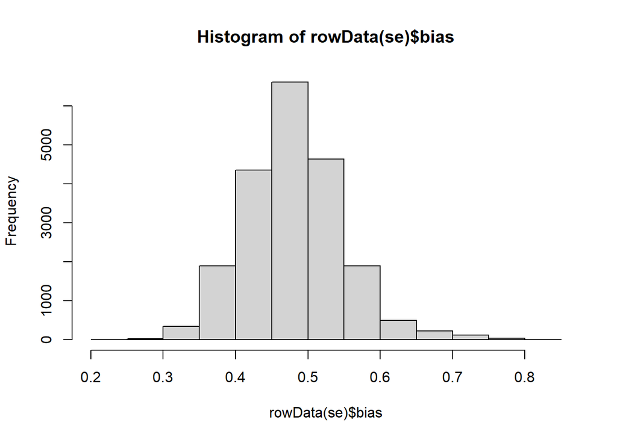

```r
colData(se)$condition <- c("CTRL","CTRL","CTRL","CTRL","CTRL","CTRL","FSS","FSS","FSS","FSS","FSS","FSS")
colData(se)$sex <- c("F","F","F","M","M","M","F","F","F","M","M","M")
row.names(se) <- as.character(granges(se))

se <- chromVAR::addGCBias(se, genome=genome_seqs)
hist(rowData(se)$bias)
```

```r
# Added bias column, most have 50% GC no clear difference to either side
```

```r
# Check which peaks contain which motif
moi <- motifmatchr::matchMotifs(motifs, subject=se, genome=genome_seqs)
# 400 motifs, 6 for each animal

# ensure reproducibility
set.seed(1234)
# Get background
bg <- chromVAR::getBackgroundPeaks(se, niterations=500)
# for each motif, we computed per-sample deviations relative to the background
# annotations tells in which peak is which motif
dev <- chromVAR::computeDeviations(object = se, annotations=moi,
                                   background_peaks=bg)
```

## Differential analysis

Prepare model matrices

```r
# Set base condition
dev$condition <- factor(dev$condition)
dev$condition <- relevel(dev$condition, "CTRL")
dev$sex <- factor(dev$sex)
dev$sex <- relevel(dev$sex, "M")
# Specify formula
mm_conditions <- model.matrix(~condition, data=as.data.frame(colData(dev)))
mm_sex <- model.matrix(~sex, data=as.data.frame(colData(dev)))
mm_double <- model.matrix(~condition*sex, data=as.data.frame(colData(dev)))
```

Fit model for condition and sex comparison

```r
# Fit model
fit_conditions <- limma::eBayes(limma::lmFit(object = assays(dev)$z, design = mm_conditions))
fit_sex <- limma::eBayes(limma::lmFit(object = assays(dev)$z, design = mm_sex))
fit_double <- limma::eBayes(limma::lmFit(object = assays(dev)$z, design = mm_double))
# we select, from the columns of model.matrix `mm`, the coefficient we want to test:
res_conditions <- as.data.frame(limma::topTable(fit_conditions, coef="conditionFSS", number = Inf))
res_sex <- as.data.frame(limma::topTable(fit_sex, coef="sexF", number = Inf))
res_double <- as.data.frame(limma::topTable(fit_double, coef = c("conditionFSS", "sexF"), number = Inf))
```

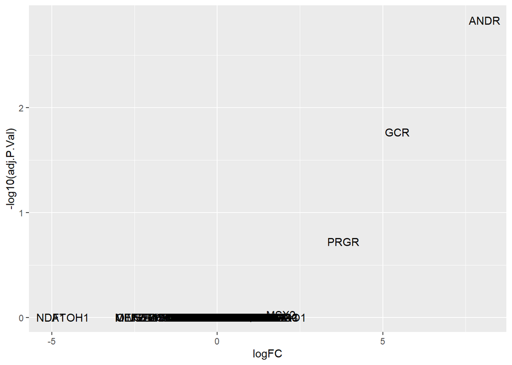

```r
# Plot logFC and p-values to identify most significant motifs
res_conditions$TF <- row.names(res_conditions)
res_sex$TF <- row.names(res_sex)
res_double$TF <- row.names(res_double)
# Relevant motifs for CTRL vs. FSS
ggplot(res_conditions, aes(logFC, -log10(adj.P.Val), label=TF)) + geom_text()
```

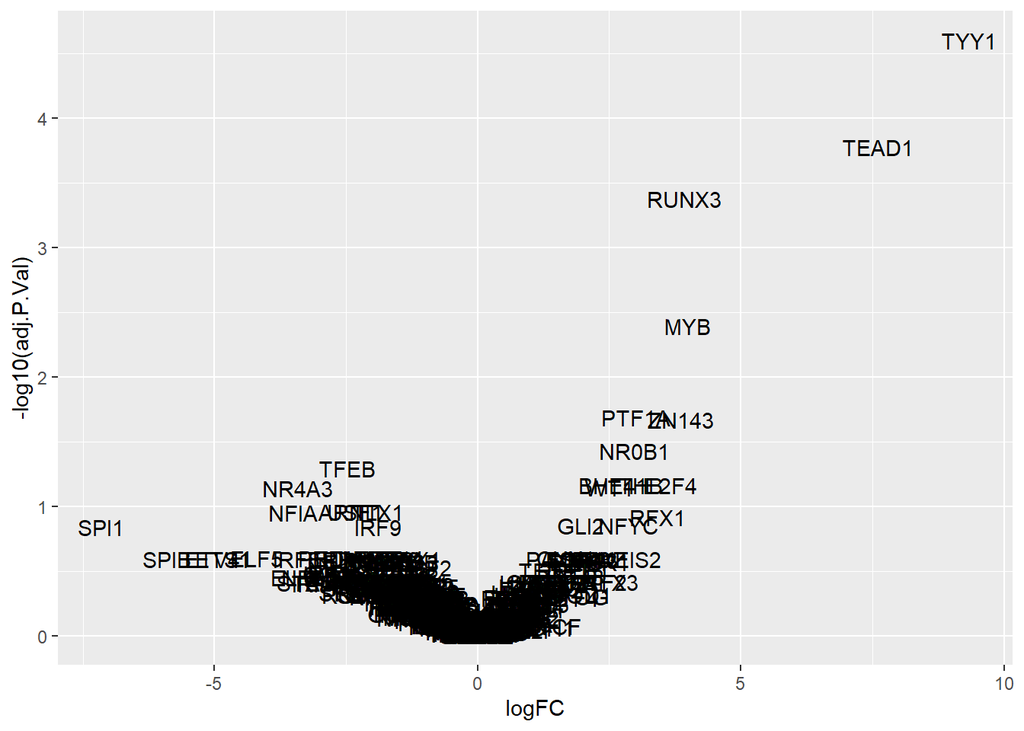

```r
# Relevant motifs for M vs. F
ggplot(res_sex, aes(logFC, -log10(adj.P.Val), label=TF)) + geom_text()
```

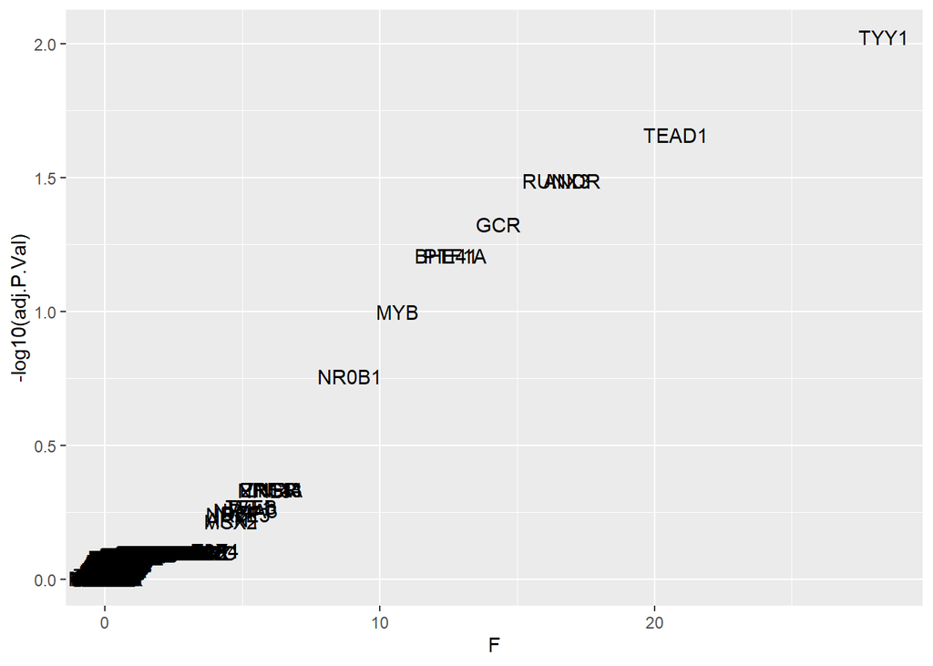

```r
# Combination of the two, plot with F instead of logFC
ggplot(res_double, aes(F, -log10(adj.P.Val), label=TF)) + geom_text()
```

## Plot heatmaps

Control vs. FSS

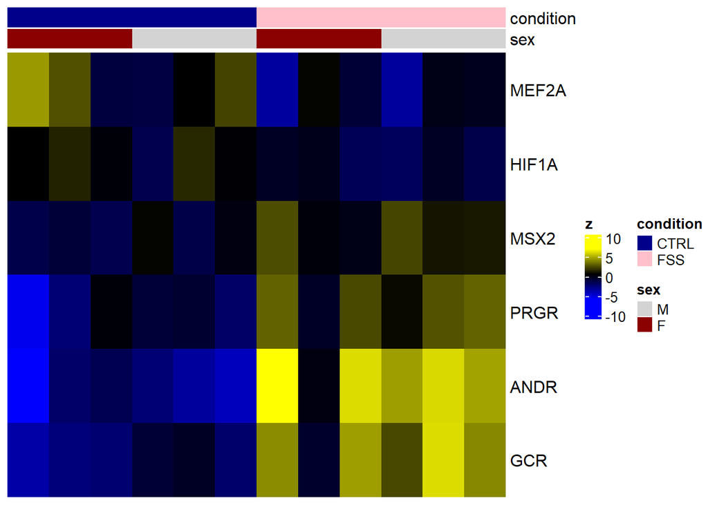

```r
metadata(dev)$anno_colors <- list(sex=c(M="lightgrey", F="darkred"), condition=c(CTRL="darkblue", FSS="pink"))
sechm::sechm(dev, features = head(row.names(res_conditions)), assayName="z", top_annotation = c("condition", "sex"))
```

Male vs. Female

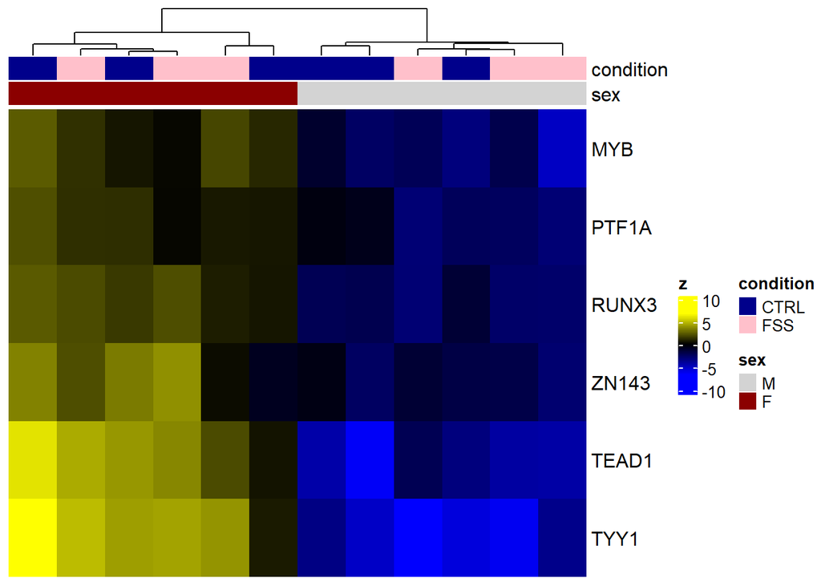

```r
sechm::sechm(dev, features = head(row.names(res_sex)), cluster_cols=TRUE, assayName="z", top_annotation = c("condition", "sex"))
```

Bonus heatmap for the combination

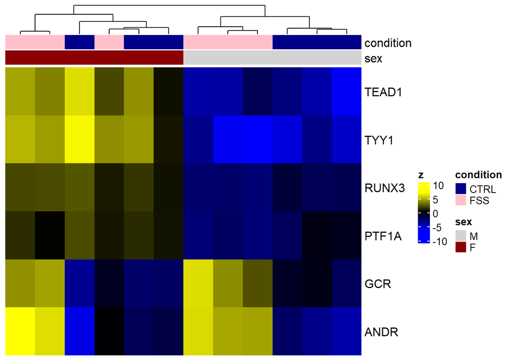

```r
sechm::sechm(dev, features = head(row.names(res_double)), cluster_cols=TRUE, assayName="z", top_annotation = c("condition", "sex"))
```

## Interpretation

If the sex difference is observed the number of peaks overlapping motifs is more variable, more motifs show some change but most are not significantly different. TYY1, TEAD1, ZN143, RUNX3, PTF1A and MYB show the biggest differences. All of them are on average more often overlapped by peaks in females compared to males, which is shown in the heatmap.

(Additional for the double:) In the plot and heatmap for sex and condition with interaction, a mixture of the previously reported motifs from the individual tests shows up. In the heatmap it doesn’t look like there are clear differences for condition and sex at the same time, the blocks are separated quite clearly by sex OR condition. This might show, that there is no big difference for the combination of the two traits, the selection simply chooses what is different for either one state.